# What Affects Borrower's APR

## by Yousef Barnawi

## Investigation Overview

> In this project, I did an extensive invistigation on loan data to determine what are the properties or features the borrower should achive before applying for a loan

## Dataset Overview

> The datast I worked on has an extensive breakdown for obtained loans. It has everything, from loan amount and APR to whether the borrower has a home or not.

## Visualization 1: APR Distribution

> After gathering the data, it was time to plot the distribution of APR. Before polishing the graph, I obtained the one on the right which somewhat resembles a normal distribution. I had to use smaller bins (Left) to look for any patterns and I found that the value 0.35797 repeats a lot, after some invistigation it looks to be an amount that is given to a lot of lower ranked borrowers in the Prosper Rating.

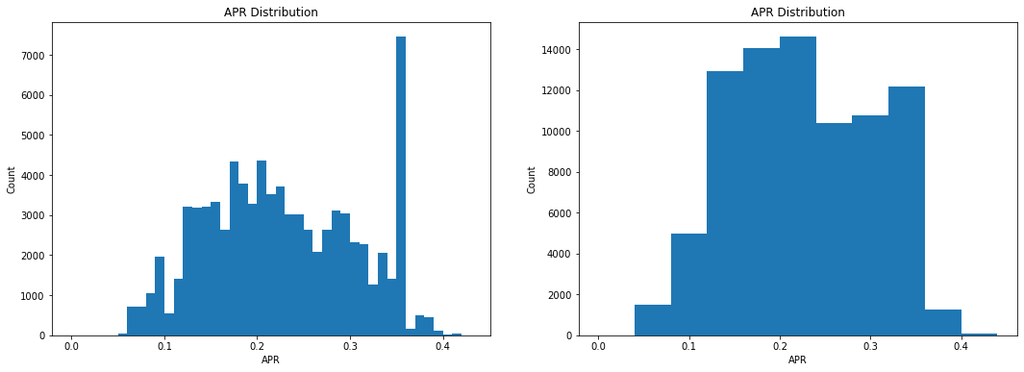

## Visualization 2: Numeric's Heatmap

> Looking to see how our variables interact with each other I decided to make a heat map that shows our numeric values against APR. Expectedly, it appears that the higher person's monthly income the more likely he will get a lower APR. The same thing somewhat fgoes to the Current and Open credit lines. At about 10, the borrower would have a better APR.

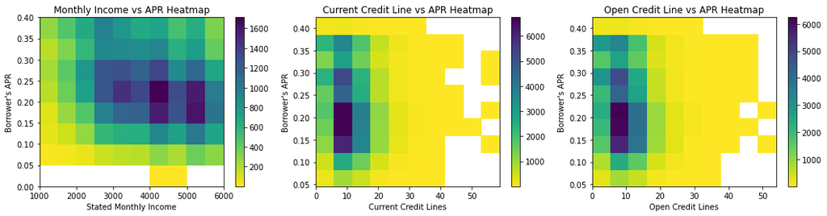

## Visualization 3: Categorical heatmap

> To better understand our main inerest data I decided to do a categorical vs categorical heat map. It shows the income range for our most common 15 occupation. Execs, Computer Programmers appear to be the ones with the higher income range.

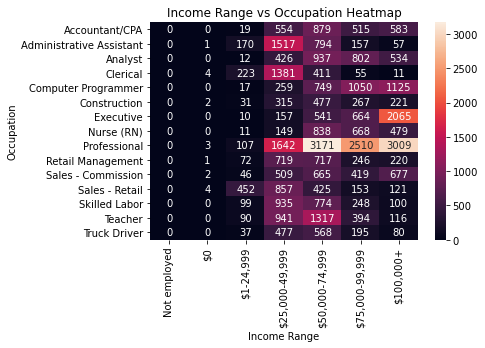

## Visualization 4: APR vs Income Range vs Home

> With Multivariate graphs we can better understand our main features. Finally let's see how one's APR compare in case of getting the same income but what differs is not having Home. Well, it appears that having home is associated with better APR.

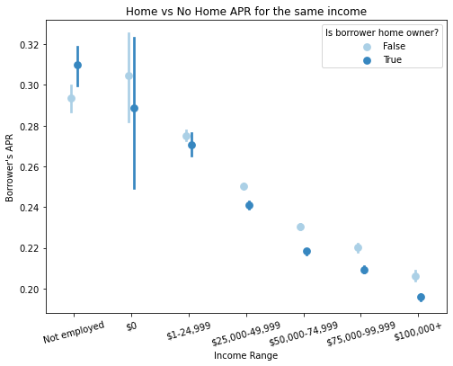